# Ctrl_labs_EMG

## Take-Home Exercise: Instructions

Please don’t spend more than 4-6 hours on this -- both out of consideration for your time, and also out of fairness to other candidates who can’t spend more time than that.

Download the Data Folder from https://archive.ics.uci.edu/ml/datasets/sEMG+for+Basic+Hand+movements.

Analyze the data in "Database 1" with the following goals:

Inspect the data to expose any features that will inform your modeling efforts.

From the EMG signals, can you distinguish the different grasps within a single user?

Can you distinguish the different grasps in a way that generalizes across users?

Optional, i.e. only if you have time. Can you identify the user from the EMG data? Do you need to know what gesture is being performed to do this?

Submitting your code:

Please submit your code, results, and interpretations in an IPython notebook (or similarly communicative medium if not using Python). Explain your reasoning for trying your approaches, and please include any results for approaches that didn't work out as well as expected.

We use a blind reviewing process, so don’t include your name or any identifying information in the write-up.

You can zip up and email your work to ben@ctrl-labs.com.

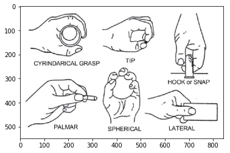

```python
import matplotlib.image as mpimg
img = mpimg.imread('sEMG_Basic_Hand_movements_upatras/grasps_en.png')
plt.imshow(img)
```

# Introduction

This is a good exercise/test about signal classification. With limited time, I have done something simple, but at least works. I didn't have enough time to improve or tune everything, but I will talk about my ideas behinde each step, and my thoughts for potential ways to improve the results. I think those are what the interviewers care about.

### In brief, I have done the following:

Q: From the EMG signals, can you distinguish the different grasps within a single user?  
A: I train the classifier to detect different grasps of individuals.  
In dataset 1  
Female 1  
Train error: 0.973 Test error 0.933  
Female 2  
Train error: 0.982 Test error 0.9472  
Female 3  
Train error: 0.897 Test error 0.817  
Male 1  
Train error: 0.947 Test error 0.867  
Male 2  
Train error: 0.975 Test error 0.961

Train error: 0.935 Test error 0.840

Q: Optional, i.e. only if you have time. Can you identify the user from the EMG data? Do you need to know what gesture is being performed to do this?  
A: I train the classifier to detect users. I use all gestures here.

Train error: 0.923 Test error 0.911

```python
import scipy.io as sio
from scipy import signal
import scipy
import matplotlib.pyplot as plt
import numpy as np
import math
from PyEMD import EMD
```

```python
# some basic parameters of the dataset
Fs = 500 # sampling frequency is 500 Hz
dt = 1/500 # sampling time resolution 2 ms
Len = spher_ch1.shape[1] # 6 sec long recording
Ntrials = 30 # each matrix has 30 trials
print(Len)
```

```
3000
```

## Notch filter

According to the data description, "The signals were band-pass filtered using a Butterworth Band Pass filter with low and high cutoff at 15Hz and 500Hz respectively and a notch filter at 50Hz to eliminate line interference artifacts." As shown in the spectrum below, it seems the signal is filtered with band-pass filer, but the 50Hz artifact still exists. So I remove it here.

```
Text(0.5,1,'notch filtered spectrum')
```

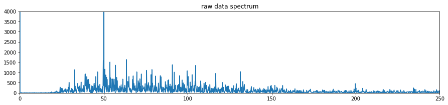

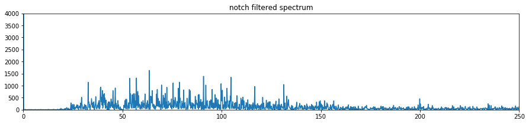

```python
user = 'female_1'
Data = sio.loadmat('sEMG_Basic_Hand_movements_upatras/Database 1/'+user+'.mat')

spher_ch1 = Data['spher_ch1']
spher_ch2 = Data['spher_ch2']

tip_ch1 = Data['tip_ch1']
tip_ch2 = Data['tip_ch2']

palm_ch1 = Data['palm_ch1']
palm_ch2 = Data['palm_ch2']

lat_ch1 = Data['lat_ch1']
lat_ch2 = Data['lat_ch2']

cyl_ch1 = Data['cyl_ch1']
cyl_ch2 = Data['cyl_ch2']

hook_ch1 = Data['hook_ch1']
hook_ch2 = Data['hook_ch2']

#---------------------------
# data = spher_ch1[4,:]
data = palm_ch1[10,:]
ps = np.abs(np.fft.fft(data))**2

time_step = dt
freqs = np.fft.fftfreq(data.size, time_step)
idx = np.argsort(freqs)

# plt.figure(figsize=(15,3))
# fig = plt.plot(data)

plt.figure(figsize=(15,3))
plt.plot(freqs[idx], ps[idx])
plt.ylim(0, 4000)
plt.xlim(0, 250)
plt.title('raw data spectrum')
#---------------------------
f0 = 50.0  # Frequency to be removed from signal (Hz)
Q = 30.0   # Quality factor
w0 = f0/(Fs/2)  # Normalized Frequency
iirnotch_b, iirnotch_a = signal.iirnotch(w0, Q)
dataf = signal.filtfilt(iirnotch_b,iirnotch_a,data)

data = dataf
ps = np.abs(np.fft.fft(data))**2
#---------------------------
time_step = 1 / 500
freqs = np.fft.fftfreq(data.size, time_step)
idx = np.argsort(freqs)

# plt.figure(figsize=(15,3))
# fig = plt.plot(data)

plt.figure(figsize=(15,3))
plt.plot(freqs[idx], ps[idx])
plt.ylim(0, 4000)
plt.xlim(0, 250)
plt.title('notch filtered spectrum')
```

## Empirical Mod Decomposition (EMD)

I follow the paper by Sapsanis, Christos, et al to extract the features. The method is based on Empirical Mod Decomposition (EMD). I use first 3 IMFs. The block below presents an example.

Sapsanis, Christos, et al. "Improving EMG based classification of basic hand movements using EMD." Engineering in Medicine and Biology Society (EMBC), 2013 35th Annual International Conference of the IEEE. IEEE, 2013.

```
(8, 350)
```

```
Text(0.5,1,'Residual (green)')
```

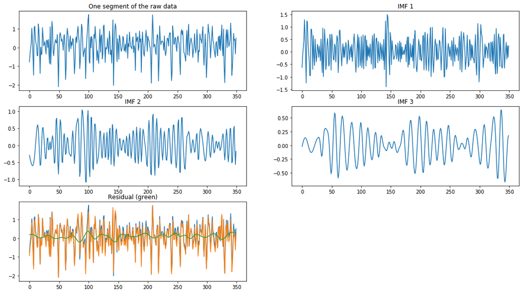

```python
sliding_window_start= 1500
window_width = 350
sliding_window = np.arange(sliding_window_start,sliding_window_start+window_width)
IMFid = np.array([0,1,2])

# data = palm_ch1[10,1000:1150]
data = cyl_ch1[10,sliding_window]

data = signal.filtfilt(iirnotch_b,iirnotch_a,data)

emd = EMD()
IMFs = emd(data)
assembly = IMFs[IMFid].sum(axis=0)

print(IMFs.shape)

plt.figure(figsize=(18,10))
plt.subplot(321)
fig = plt.plot(data)
plt.title('One segment of the raw data')
plt.subplot(322)
fig = plt.plot(IMFs[0,:])
plt.title('IMF 1')
plt.subplot(323)
fig = plt.plot(IMFs[1,:])
plt.title('IMF 2')
plt.subplot(324)
fig = plt.plot(IMFs[2,:])
plt.title('IMF 3')
plt.subplot(325)
fig = plt.plot(data)
fig = plt.plot(assembly)
fig = plt.plot(data-assembly)
plt.title('Residual (green)')
```

## list of features

The function to extract features. The features are

1. Integrated EMG
2. Zero crossings
3. Variance
4. Slope sign changes
5. Waveform length
6. Kurtosis
7. Skewness

Feature extraction is always the most important step, those parametric methods of course are not enough. If I have time, I will move on to the nonparametric method, such as dictionary learning, convolutional neural network, or similar classifier.

```python
# input: Trial, \
#          sliding_window_start, \
#          IMFid,\
#          window_width,\
#          iirnotch_b,\
#          iirnotch_a
# output: X, you can image I have wrote good comments here
def extract_features_from_each_trial(Trial, \
                                     sliding_window_start, \
                                     IMFid,\
                                     window_width,\
                                     iirnotch_b,\
                                     iirnotch_a):

    Trial = signal.filtfilt(iirnotch_b,iirnotch_a,Trial)
    X = 0

    for win_s in sliding_window_start:
        sliding_window = np.arange(win_s,win_s+window_width)
        data = Trial[sliding_window]

        emd = EMD()
        IMFs = emd(data)
        assembly = IMFs[IMFid].sum(axis=0)
        residual = data - assembly
        X_stack = np.vstack((data, IMFs[IMFid], residual))

        IEMG = np.abs(X_stack).mean(axis=1)
        ZC = (np.abs(np.diff(np.sign(X_stack)))/2).sum(axis=1)
        VAR = np.var(X_stack, axis=1)
        SSC = (np.abs(np.diff(np.sign( np.diff(X_stack) )))/2).sum(axis=1)
        WL = np.abs(np.diff(X_stack)).sum(axis=1)
        WAMP = np.abs(np.diff(X_stack))

        Kurtosis = scipy.stats.kurtosis(X_stack, axis=1)
        Skew = scipy.stats.skew(X_stack, axis=1)

        X_session = np.hstack((IEMG,ZC,VAR,SSC,WL,Kurtosis,Skew))
        X = X + X_session
#         X = np.hstack((X, X_session))
#         print(X.shape)

#     print(sliding_window_start.shape[0])
    X = X / sliding_window_start.shape[0]

    return X
```

## Run features extraction and save features

```python
user = 'female_2'
Data = sio.loadmat('sEMG_Basic_Hand_movements_upatras/Database 1/'+user+'.mat')

spher_ch1 = Data['spher_ch1']
spher_ch2 = Data['spher_ch2']

tip_ch1 = Data['tip_ch1']
tip_ch2 = Data['tip_ch2']

palm_ch1 = Data['palm_ch1']
palm_ch2 = Data['palm_ch2']

lat_ch1 = Data['lat_ch1']
lat_ch2 = Data['lat_ch2']

cyl_ch1 = Data['cyl_ch1']
cyl_ch2 = Data['cyl_ch2']

hook_ch1 = Data['hook_ch1']
hook_ch2 = Data['hook_ch2']

channel_name_list = ['spher_ch1', 'spher_ch2', \
                     'tip_ch1', 'tip_ch2',\
                     'palm_ch1', 'palm_ch2',\
                     'lat_ch1', 'lat_ch2',\
                     'cyl_ch1', 'cyl_ch2',\
                     'hook_ch1', 'hook_ch2']
```

```python
# Process data to extract features

channel_name_list = ['spher_ch1', 'spher_ch2', \
                     'tip_ch1', 'tip_ch2',\
                     'palm_ch1', 'palm_ch2',\
                     'lat_ch1', 'lat_ch2',\
                     'cyl_ch1', 'cyl_ch2',\
                     'hook_ch1', 'hook_ch2']

# design notch filter
f0 = 50.0  # Frequency to be removed from signal (Hz)
Q = 30.0   # Quality factor
w0 = f0/(Fs/2)  # Normalized Frequency
iirnotch_b, iirnotch_a = signal.iirnotch(w0, Q)

window_width = 350
sliding_window_start= np.arange(200, 3000-window_width, 100)
IMFid = np.array([0,1,2]) # IMF index, here I select first 3

for channel_name in channel_name_list:
    all_features = np.zeros((Ntrials,35))
    print(channel_name)
    for tid in range(Ntrials):
#         print(tid)
        exec('Trial = '+ channel_name +'[tid,:]')
        X = extract_features_from_each_trial(Trial, sliding_window_start,\
                                             IMFid, window_width, iirnotch_b,iirnotch_a)
        all_features[tid,:] = X

    np.save('features/Database1_'+user+'_'+channel_name, all_features)
```

[output not shown]

## Features loader

```python
# load saved features and their labels

# input: user,\
#          channel_name_list,\
#          col,\
#          normalization=False
# output: X_all, Y_all
def build_train_test_dataset(user,\
                             channel_name_list,\
                             col,\
                             normalization=False):
    X_all = np.empty(0)
    Y_all = np.empty(0)

    for cnt, channel_name in enumerate(channel_name_list):
        X_sub = np.empty(0)
        Y_sub = np.empty(0)
        for chID in [1,2]:
            X_subsub = np.load('features/Database1_'+user+'_'+channel_name+str(chID)+'.npy')

            if X_sub.size == 0:
                X_sub = X_subsub[:,col]
            else:
                X_sub = np.hstack((X_sub, X_subsub[:,col]))

        if X_all.size == 0:
            X_all = X_sub
            Y_all = np.ones(X_sub.shape[0])*cnt
        else:
            X_all = np.vstack((X_all, X_sub))
            Y_all = np.hstack((Y_all, np.ones(X_sub.shape[0])*cnt))

    if normalization:
        X_all = X_all - X_all.mean(axis=0)
        X_all = X_all / X_all.std(axis=0)

    return X_all, Y_all
```

# Signal classification

I use the same classification algorithm for the following tasks. It is an sklearn build-in method. Any equivalent nonlinear decision boundary algorithm should work as good as this.

## Train classifier to detect grasps of an individual

```python
# All features of 5 users from dataset 1

channel_name_list = ['spher_ch',\
                     'tip_ch',\
                     'palm_ch',\
                     'lat_ch',\
                     'cyl_ch',\
                     'hook_ch']

col = np.array(range(35)) # select feature index (totally 5*7)

user = 'male_2'
X_all, Y_all = build_train_test_dataset(user, channel_name_list, col, True)

print(X_all.shape)
print(Y_all.shape)
```

```
(180, 70)
(180,)
```

```python
# running classification here

from sklearn.model_selection import train_test_split
from sklearn import svm
from sklearn.gaussian_process import GaussianProcessClassifier
from sklearn.gaussian_process.kernels import RBF

score_train = np.zeros(10)
score_test = np.zeros(10)

# train and test using cross validation
for i in range(10):
    X_train, X_test, Y_train, Y_test = train_test_split(X_all, Y_all, test_size=0.2, random_state=i)

    kernel = RBF(5)
    clf = GaussianProcessClassifier(kernel=kernel,random_state=5).fit(X_train, Y_train)

    score_train[i] = clf.score(X_train, Y_train)
    score_test[i] = clf.score(X_test, Y_test)

print('Train error: {}  Test error {}'.format(score_train.mean(), score_test.mean()) )
```

```
Train error: 0.9749999999999999  Test error 0.961111111111111
```

This is actually an interesting question itself. The idea behind is to merge different user's feature, and make them look like they come from the same distribution. This is also related to state-or-the-art research about differential privacy. The idea is how can you remove the infomation associated with each user. My method is quite simple, just mean, std normalization.

```python
# All features of 5 users from dataset 1

channel_name_list = ['spher_ch',\
                     'tip_ch',\
                     'palm_ch',\
                     'lat_ch',\
                     'cyl_ch',\
                     'hook_ch']

col = np.array(range(35)) # select feature index (totally 5*7)

user = 'female_1'
X_all_1, Y_all_1 = build_train_test_dataset(user, channel_name_list, col, True)

user = 'female_2'
X_all_2, Y_all_2 = build_train_test_dataset(user, channel_name_list, col, True)

user = 'female_3'
X_all_3, Y_all_3 = build_train_test_dataset(user, channel_name_list, col, True)

user = 'male_1'
X_all_4, Y_all_4 = build_train_test_dataset(user, channel_name_list, col, True)

user = 'male_2'
X_all_5, Y_all_5 = build_train_test_dataset(user, channel_name_list, col, True)

# print(X_all_3.shape)
# print(Y_all_3.shape)

X_all = X_all_2
Y_all = Y_all_2

Y_user_1 = 0 * np.ones(Y_all_1.shape)
Y_user_2 = 1 * np.ones(Y_all_1.shape)
Y_user_3 = 2 * np.ones(Y_all_1.shape)
Y_user_4 = 3 * np.ones(Y_all_1.shape)
Y_user_5 = 4 * np.ones(Y_all_1.shape)

Y_all = np.hstack((Y_user_1, Y_user_2, Y_user_3, Y_user_4, Y_user_5))
X_all = np.vstack((X_all_1, X_all_2, X_all_3, X_all_4, X_all_5))

print(X_all.shape)
print(Y_all.shape)
```

```
(900, 70)
(900,)
```

```python
# running classification here

from sklearn.model_selection import train_test_split
from sklearn import svm
from sklearn.gaussian_process import GaussianProcessClassifier
from sklearn.gaussian_process.kernels import RBF

score_train = np.zeros(10)
score_test = np.zeros(10)

# train and test using cross validation
for i in range(10):
    X_train, X_test, Y_train, Y_test = train_test_split(X_all, Y_all, test_size=0.2, random_state=i)

    kernel = RBF(5)
    clf = GaussianProcessClassifier(kernel=kernel,random_state=5).fit(X_train, Y_train)

    score_train[i] = clf.score(X_train, Y_train)
    score_test[i] = clf.score(X_test, Y_test)

print('Train error: {}  Test error {}'.format(score_train.mean(), score_test.mean()) )
```

```
Train error: 0.9348611111111111  Test error 0.8400000000000001
```

## Train the classifier to detect users

```python
# All features of 5 users from dataset 1

channel_name_list = ['spher_ch',\
                     'tip_ch',\
                     'palm_ch',\
                     'lat_ch',\
                     'cyl_ch',\
                     'hook_ch']

col = np.array(range(35)) # select feature index (totally 5*7)

user = 'female_1'
X_all_1, Y_all_1 = build_train_test_dataset(user, channel_name_list, col, False)

user = 'female_2'
X_all_2, Y_all_2 = build_train_test_dataset(user, channel_name_list, col, False)

user = 'female_3'
X_all_3, Y_all_3 = build_train_test_dataset(user, channel_name_list, col, False)

user = 'male_1'
X_all_4, Y_all_4 = build_train_test_dataset(user, channel_name_list, col, False)

user = 'male_2'
X_all_5, Y_all_5 = build_train_test_dataset(user, channel_name_list, col, False)


Y_user_1 = 0 * np.ones(Y_all_1.shape)
Y_user_2 = 1 * np.ones(Y_all_1.shape)
Y_user_3 = 2 * np.ones(Y_all_1.shape)
Y_user_4 = 3 * np.ones(Y_all_1.shape)
Y_user_5 = 4 * np.ones(Y_all_1.shape)

Y_all = np.hstack((Y_user_1, Y_user_2, Y_user_3, Y_user_4, Y_user_5))
X_all = np.vstack((X_all_1, X_all_2, X_all_3, X_all_4, X_all_5))
```

```python
# running classification here

from sklearn.model_selection import train_test_split
from sklearn import svm
from sklearn.gaussian_process import GaussianProcessClassifier
from sklearn.gaussian_process.kernels import RBF

CV_number = 10

score_train = np.zeros(CV_number)
score_test = np.zeros(CV_number)

# train and test using cross validation
for i in range(CV_number):
    X_train, X_test, Y_train, Y_test = train_test_split(X_all, Y_all, test_size=0.2, random_state=i)

    kernel = RBF(500)
    clf = GaussianProcessClassifier(kernel=kernel,random_state=5).fit(X_train, Y_train)

    score_train[i] = clf.score(X_train, Y_train)
    score_test[i] = clf.score(X_test, Y_test)

#     print(score_train[i], score_test[i])

print('Train error: {}  Test error {}'.format(score_train.mean(), score_test.mean()) )
```

```
Train error: 0.9233333333333335  Test error 0.9111111111111112
```